# R Notebook

Week 10 - day 1

What is linear regression? A linear way of modelling the relationship between two variables, which can be used to predict / forecast models

## Correlations

positive correlation - y increases, as x increases

Negative correlation - y decreases as x increases

Strong/weak correlation - measured by correlation coeffecient ( -1 / +1) When r = 1, then there is a linear correlation (?)

cor()

Task

Change the noise and gradient values

```r
library(janitor)
```

Covariance

cov()

Strength of correlation

As written out by one author (JD Evans)

0 - none 0.01 - 0.19 - very weak 0.2 - 0.39 - weak 0.4 - 0.59 - moderate 0.6 - 0.79 - strong

To calculate correlation: cor()

Task

Use anscombe dataset to calculate correlation coeffecients

```r
cor(anscombe$x4, anscombe$y4)
```

```
[1] 0.8165214
```

Task - 2 mins See if you can suggest any confounding variable(s) for the following associations: “1. Sleeping with shoes on is strongly correlated with waking up with a headache. Therefore, sleeping with shoes on causes headaches.”

“2. Atmospheric CO2 level and obesity levels have both increased sharply since the 1950s. Therefore, atmospheric CO2 causes obesity.”

“3. The more bacon someone eats, the higher their blood pressure. Therefore bacon causes hypertension.”

Task - find any correlations / plots with strong / weak correlations

```r
tibble_states <- clean_names(as_tibble(state.x77))

cor(tibble_states$illiteracy, tibble_states$murder)

pairs()
# plots everything at once

psych::pairs_panels()
```

## Lines (2nd lesson)

Independent variable - x

y - is a function of x (so therefore, y is dependent, and x is independent)

predictor vs response explanatory vs outcome

formula: y = a*x + b (intercept formula)

a = gradient b = intercept

gradient = slope intercept =

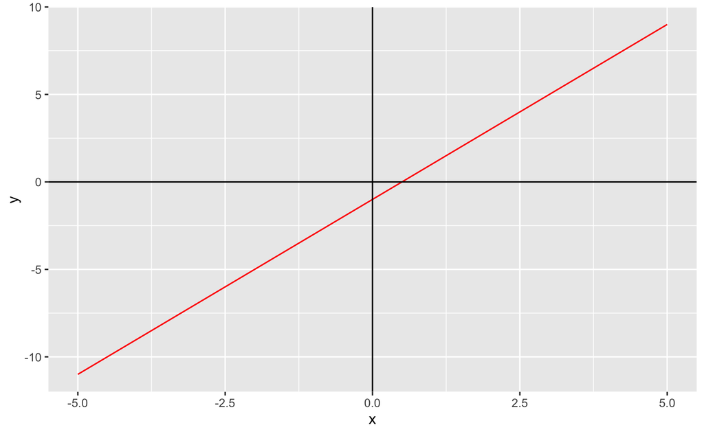

Task

Play around plotting two or three different lines. Try a line with a=0 and positive b. You can use mutate() to overwrite y in data from above Can we use our line() function to plot a perfectly vertical line?

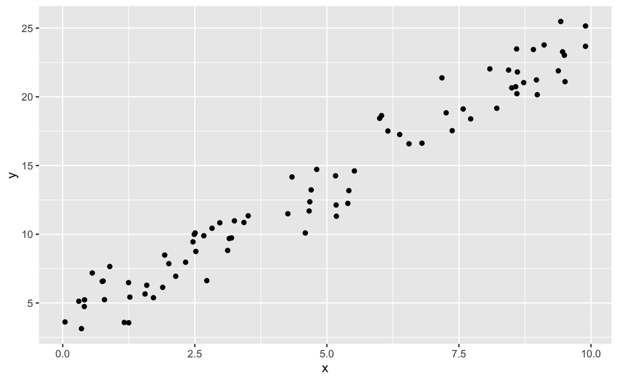

putting in the centroid (centre point of the graph / the mean of the means)

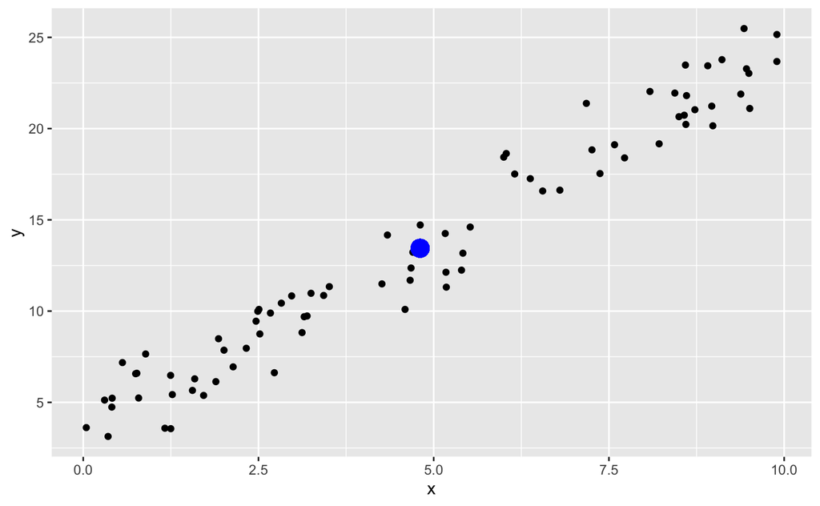

Now we add the intercept, so that we have a line / multiple points to add a line

To calculate this: y - a*x = b

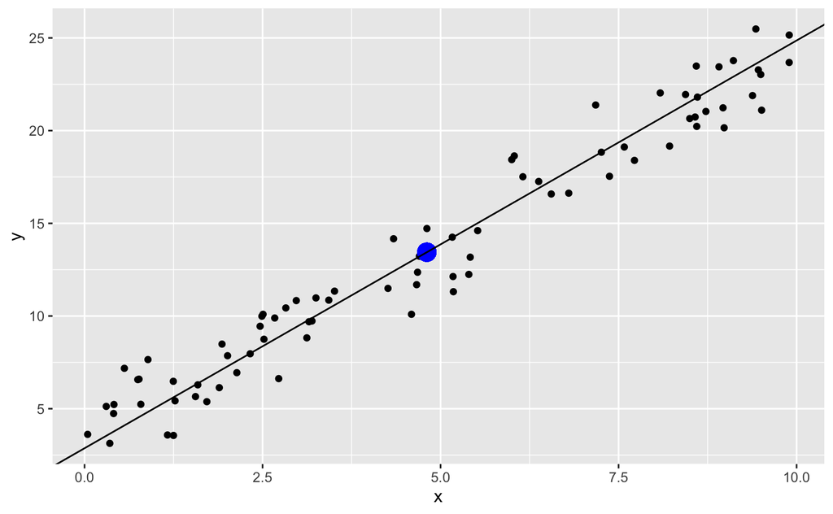

When we talk about modelling, we talk about that line (the line through the middle of the graph), and this allows us to generalise and talk about the graph (and predict!)

LUNCH BREAK

## Linear regression

lm()

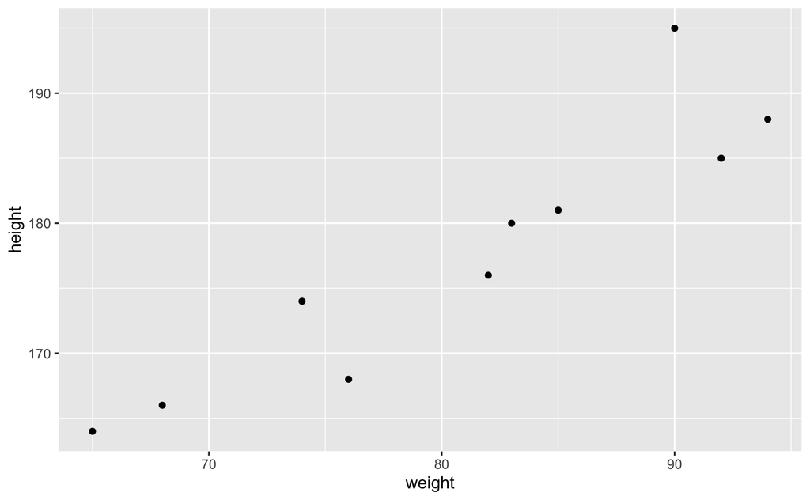

y = b0 + b1 * x

b0 = intercept b1 = slope

making a plot for sample_data

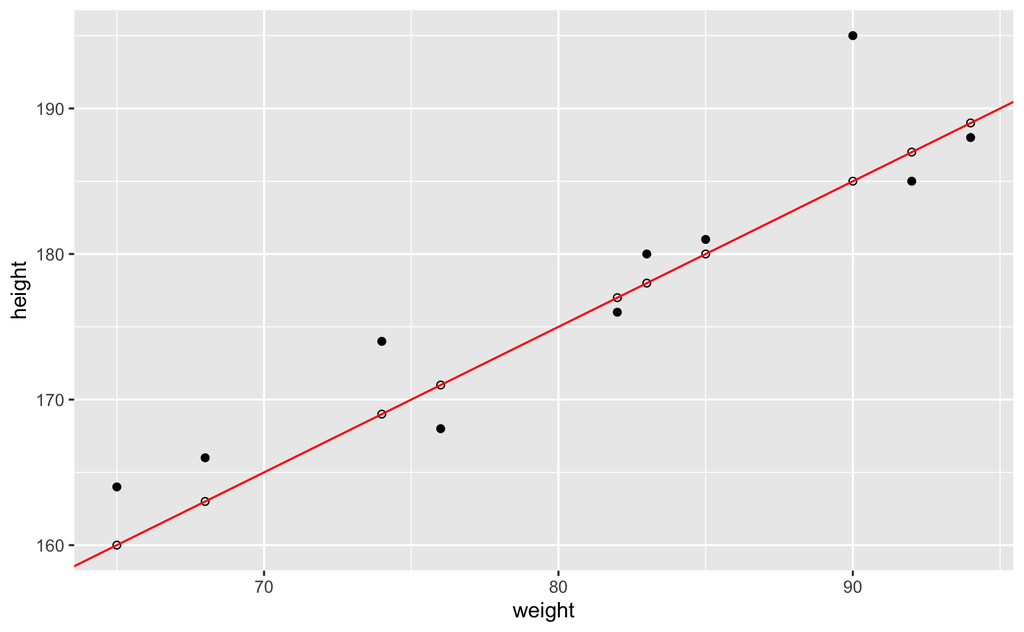

| sum_sq_residual |
| --- |
| 170 |

Making a linear model

```r
lm(height ~ weight, sample_data)
```

```
Call:
lm(formula = height ~ weight, data = sample_data)

Coefficients:
(Intercept)       weight
   102.1758       0.9336
```

```r
predict(new_model, newdata = predict_at)
```

```
       1
174.9927
```

```r
library(modelr)
library(tidyverse)

sample_data <- sample_data %>%
  # select(fit_height, residuals, sq_residuals) %>%
  add_predictions(new_model) %>%
  add_residuals(new_model)

sample_data %>%
  ggplot(aes(x = weight)) +
  geom_point(aes(y = height)) +
  geom_line(aes(y = pred, colour = "red"))
```

[output not shown]

```r
# sidestep - how to calculate linear regression:
x_dev <- sample$weight - mean(sample$weight)
y_dev <- sample$height - mean(sample$height)

top <- sum(x_dev * y_dev) / 9
bottom <- sum(x_dev^2 / 9)
model

top / bottom

cov(sample$weight, sample$height) /
var(sample$weight)
```

## Interpreting Linear Regressions

```r
sample_data_again <- tibble(
  height = c(176, 164, 181, 168, 195, 185, 166, 180, 188, 174),
  weight = c(82, 65, 85, 76, 90, 92, 68, 83, 94, 74 )
)

model_again <- lm(height ~ weight, data = sample_data_again)
summary(model_again)

summary(model_again)
boxplot(resid(model_again))
```

[output not shown]

```r
library(broom)

summary(model_again)

tidy_output <- janitor::clean_names(tidy(model_again))
glance_output <- janitor::clean_names(glance(model_again))
```

r_squared is the proportion of the variation that can be explained by variation in the predictor(s)

```r
# regression diagnostics

library(ggfortify)

autoplot(model_again)
```

[output not shown]

Task

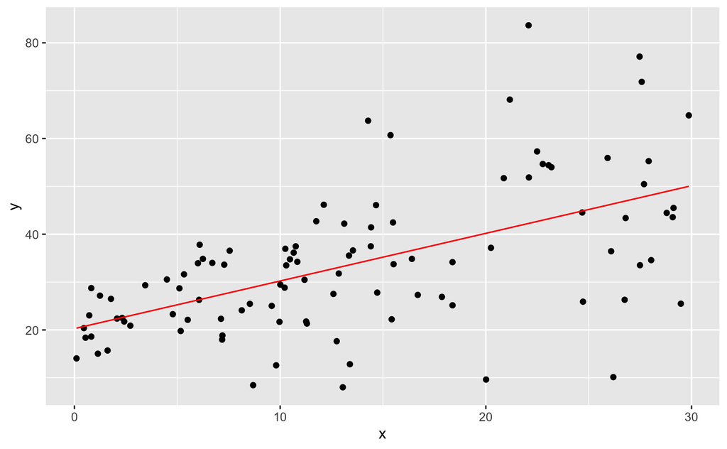

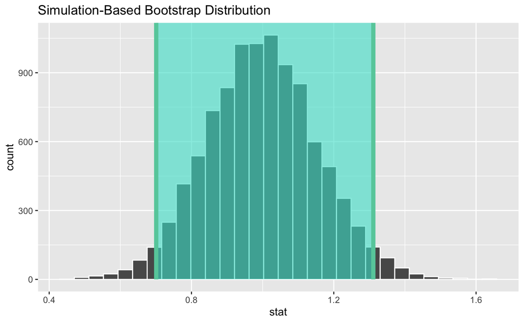